# Data of stable isotope composition of atmospheric water input beetween 2012 and 2014 at the southern slopes of Mt. Kilimanjaro, Tanzania

Insa Otte, Florian Detsch, Adrian Gütlein, Martha Scholl, Ralf Kiese, Tim Appelhans, Thomas Nauss

7 1 2021

## Overview

The dataset provides detailed information about the stable isotope composition of different precipitation types (rainf, fog, throughfall). It was manually collected on up to 9 study plots on a generally weekly basis between November 2012 and November 2014. The following map shows the distribution of the study plots on the southern slopes of Mt. Kilimanjaro.

The study plots span across an altitude gradient rising from 950 m to nearly 4,000 m a.s.l. The plot IDs are the ones used within the respective research group.

| PlotID | Land cover |
| --- | --- |
| fer0 | Forest Erica |
| fpd0 | Forest Podocarpus disturbed |
| fpo0 | Forest Podocarpus |
| foc0 | Forest Ocotea |
| foc6 | Forest Ocotea |
| flm1 | Forest lower mountain |
| nkw1 | Open area near field station |
| hom4 | Homegarden |
| sav5 | Savanna |

```r
mapviewOptions(basemaps = "Esri.WorldImagery")
mapview(idata, zcol = "PlotID", legend = TRUE)
```

[interactive chart not shown]

Moisture sources (- 96 hours) of the isotope samples were estimated using backward trajectory computations with the HYSPLIT model (https://www.ready.noaa.gov/HYSPLIT.php) and the R opentraj package (Thalles Santos Silva (2014). opentraj: Tools for Creating and Analysing Air Trajectory Data. R package version 1.0. https://CRAN.R-project.org/package=opentraj). Reanalysis data was taken from NCEP/NCAR version 2 ( https://www.ncdc.noaa.gov/data-access/model-data/model-datasets/reanalysis-1-reanalysis-2).

For further details see reference at the end of this document.

## Datasets

Precipitation was sampled from rain gauges, fog mesh grids and throughfall installations on the study plots. Throughfall has been measured by many gauges placed across the study plot. These gauges are named “Bnn” with nn being an integer number in the field and lab records. To get the mean throughfall of the respective time slot, the gauge data must be averaged.

Sampling was carried out manually by local field staff and recorded on paper sheets. Sampling took place about every week. Two intensive sampling campaigns with multiple daily recordings took place in December 2013 and April 2014.

| Folder | Data |
| --- | --- |
| data/field_records | Scans of the original paper sheets group by study plots |
| data/lab_records | Digitized paper sheets and isotope analysis data |
| data/compiled_data | Comprehensive dataset as Shapefile and CSV |
| /data/hysplit | Datasets related to backward trajectory computation |
| /data/hysplit/data | Site information used to compute backward trajectories |
| /data/hysplit/out/evently | Hysplit backward trajectories by event |
| /data/hysplit/out/weekly | HYSPLIT backward trajectories by week |
| /data/hysplit/reanalysis | Reanalysis data used as input for the HYSPLIT model |

The data in the compiled_data folder does not include the intensive campaigns records that are also available in the lab_records folder.

The structure of the compiled isotope dataset is as follows:

```
## Simple feature collection with 6 features and 12 fields
## geometry type:  POINT
## dimension:      XY
## bbox:           xmin: 310260.9 ymin: 9659338 xmax: 310260.9 ymax: 9659338
## projected CRS:  WGS 84 / UTM zone 37S
##   PlotID       Date     Time      Season PrcpTyp Elvton PrcpAmt   dO18 sddO18
## 1   fer0 2012-11-22 15:40:00 short rains     fog   3880   0.000     NA     NA
## 2   fer0 2012-11-29 14:15:00 short rains     fog   3880   0.000     NA     NA
## 3   fer0 2012-12-06 14:10:00 short rains     fog   3880   1.150 -7.310  0.050
## 4   fer0 2012-12-12 14:15:00 short rains     fog   3880   0.000     NA     NA
## 5   fer0 2012-12-20 15:10:00 short rains     fog   3880   0.000     NA     NA
## 6   fer0 2012-12-28 16:17:00 short rains     fog   3880   3.598 -7.071  0.094
##        dD   sdD dExcess                 geometry
## 1      NA    NA      NA POINT (310260.9 9659338)
## 2      NA    NA      NA POINT (310260.9 9659338)
## 3 -36.600 0.350   21.88 POINT (310260.9 9659338)
## 4      NA    NA      NA POINT (310260.9 9659338)
## 5      NA    NA      NA POINT (310260.9 9659338)
## 6 -35.258 0.222   21.31 POINT (310260.9 9659338)
```

The variables have the following meaning:

| Column | Content |
| --- | --- |
| PlotID | Study plot ID as used within the research group |
| Date | Date of the observation |
| Time | Time of the observation |
| Season | Type of rainy season |
| PrcpType | Type of precipitation (rain, fog, tf = throughfall) |
| Elvton | Elevation of the study plot in m a.s.l |
| PrcpAmt | Amount of recorded precipitation (rain, fog or throughfall) |
| dO18 | delta 18O/16O |
| sddO18 | standard deviation of delta 18O/16O |
| dD | delta D/H |
| sddD | standard deviation of delta D/H |
| dExcess | Deuterium excess |

The backward trajectory information computed with the Hysplit model:

```
##   receptor year month day hour hour.inc    lat    lon height pressure
## 1        1 2012    11  21    0        0 -3.340 37.680 3000.0    628.5
## 2        1 2012    11  20   23       -1 -3.357 37.639 2938.5    632.5
## 3        1 2012    11  20   22       -2 -3.382 37.593 2887.7    635.3
## 4        1 2012    11  20   21       -3 -3.415 37.543 2847.4    637.3
## 5        1 2012    11  20   20       -4 -3.456 37.489 2818.3    638.7
## 6        1 2012    11  20   19       -5 -3.505 37.434 2802.1    640.1
##                 date2       date
## 1 2012-11-21 00:00:00 2012-11-21
## 2 2012-11-20 23:00:00 2012-11-21
## 3 2012-11-20 22:00:00 2012-11-21
## 4 2012-11-20 21:00:00 2012-11-21
## 5 2012-11-20 20:00:00 2012-11-21
## 6 2012-11-20 19:00:00 2012-11-21
```

The variables have the following meaning (see Thalles Santos Silva (2014). opentraj: Tools for Creating and Analysing Air Trajectory Data. R package version 1.0. https://CRAN.R-project.org/package=opentraj):

| Column | Content |
| --- | --- |
| receptor | numeric vector |
| year | year of the calculation |
| month | month of the calculation |
| day | day of the calculation |
| hour | hour of the calculation |
| minute | minute of the calculation |
| hour.inc | time step (age) in hours of the computed trajectory |
| lat | latitude position of the trajectory |
| lon | longitude position of the trajectory |
| height | meters above ground of the trajectory |
| pressure | pressure level of the trajectory |
| date2 | Date and time of the trajectory |
| date | Start date and time of the calculation |

## Examples

The following figures shows the dO18 and dD values of the compiled dataset. The light grey line illustrates the global meteoric water line and the black line the respective local meteoric water line for all (top left), fog (top right), rain (bottom left) and throughfall (bottom right) samples.

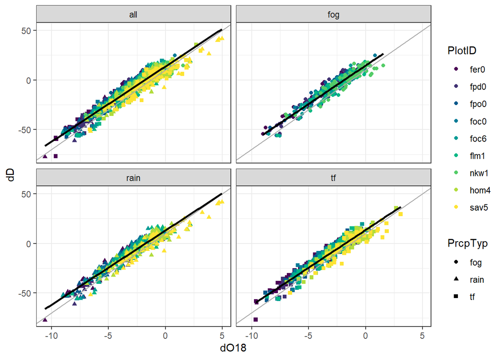

```r
facet_idata <- st_drop_geometry(idata)
facet_idata$facet <- facet_idata$PrcpTyp
facet_idata <- rbind(facet_idata, data.frame(st_drop_geometry(idata), facet = "all"))

ggplot(facet_idata, aes(x = dO18, y = dD)) +
  geom_point(aes(color = PlotID, shape = PrcpTyp)) +
  geom_abline(intercept = 10, slope = 8, color = "darkgrey") +
  geom_smooth(method = "lm", se = FALSE, color = "black") +
  facet_wrap(vars(facet)) +
  scale_color_manual(values = plotcolors) +
  theme_bw()
```

The following figures shows the seasonal dynamics of the dO18 and dExcess rainfall sample values of the compiled dataset.

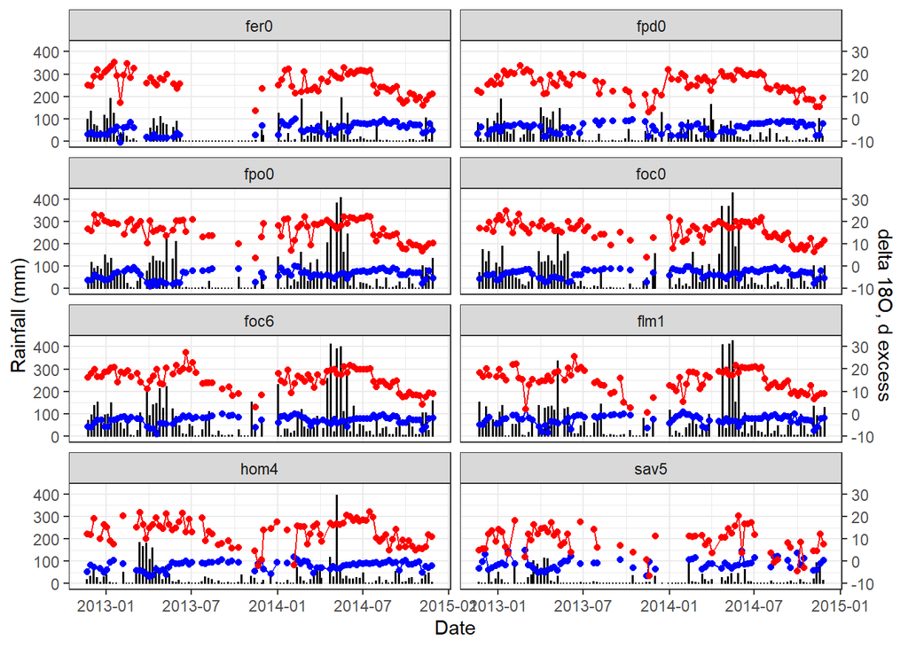

```r
ylim_1 <- c(0, 450)
ylim_2 <- c(-10, 35)

b <- diff(ylim_1) / diff(ylim_2)
a <- b * (ylim_1[1] - ylim_2[1])

ggplot(idata[idata$PrcpTyp == "rain", ], aes(x = Date, y = PrcpAmt)) +
  geom_bar(stat = "identity", color = "black") +
  geom_line(aes(y = a + b * dO18), color = "blue") +
  geom_point(aes(y = a + b * dO18), color = "blue") +
  geom_line(aes(y = a + b * dExcess), color = "red") +
  geom_point(aes(y = a + b * dExcess), color = "red") +
  scale_y_continuous("Rainfall (mm)", sec.axis = sec_axis(~ (. - a) / b, name = "delta 18O, d excess")) +
  facet_wrap(vars(PlotID), ncol = 2) +
  theme_bw()
```

The following map shows the weekly averaged hysplit trajectories.

```r
hdata_sp <- lapply(hdata, function(i){
  return(Df2SpLines(i, crs = "+init=epsg:4326"))
})
hdata_sp <- do.call(rbind, hdata_sp)
mapview(hdata_sp, label = names(hdata))
```

[interactive chart not shown]

## Related Publication

Otte I, Detsch F, Gütlein A, Scholl M, Kiese R, Appelhans T, Nauss T (2017) Seasonality of stable isotope composition of atmospheric water input at the southern slopes of Mt. Kilimanjaro, Tanzania. Hydrological Processes 31, 3932–3947. https://doi.org/10.1002/hyp.11311.

## Funding

The research was fundet by the German Research Foundation (DFG) as part of the Research Unit 1246 - Kilimanjaro ecosystems under global change (Ap 243/1‐2, Na 783/5‐2).